# individual3

3.Do ratings depend on the cacao percentage of a chocolate bar?

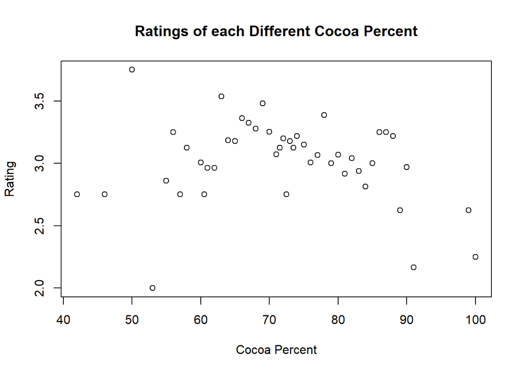

```r
grouping <- aggregate(choco$Rating,, by = list(choco$Cocoa_Percent),FUN = mean,na.rm=TRUE)
plot(grouping, xlab= "Cocoa Percent", ylab ="Rating", main="Ratings of each Different Cocoa Percent")
```

There does not seem to be any correlation between Cocoa percentage and Rating looking at this graph all the data points are everywhere

```r
twoColumnCocoa <- choco[c(4,7)]
tableChoco <- table(twoColumnCocoa)
tableChoco <- addmargins(tableChoco, 1)
tableChoco<-as.data.frame(tableChoco)
tableChoco[tableChoco$Date == 'Sum', c('Cocoa_Percent', 'Freq')]
```

```
##     Cocoa_Percent Freq
## 16             42    1
## 32             46    1
## 48             50    1
## 64             53    1
## 80             55   16
## 96             56    2
## 112            57    1
## 128            58    8
## 144            60   46
## 160          60.5    1
## 176            61    7
## 192            62   14
## 208            63   14
## 224            64   34
```

[output cut: 32 more lines]

The data set shows that many of the ratings have cocoa percent between 70 to 75 percent and that there are not that many ratings for chocolates outside of that percent.

4.How do different characteristics of the chocolate compare? To elaborate, which characteristics tend to be more favorable and which ones are not?

```r
one <- choco[, c("Rating","Characteristics1")]
one <- setNames(aggregate(one$Rating, by = list(one$Characteristics1),FUN = mean,na.rm=TRUE), c("Characteristics", "Rating"))

two <- choco[,c("Rating","Characteristics2")]
two <- setNames(aggregate(two$Rating, by = list(two$Characteristics2),FUN = mean,na.rm=TRUE), c("Characteristics", "Rating1"))
one <- merge(one, two,by= "Characteristics")

three <- choco[,c("Rating","Characteristics3")]
three <- setNames(aggregate(three$Rating, by = list(three$Characteristics3),FUN = mean,na.rm=TRUE), c("Characteristics", "Rating2"))

one <- merge(one, three,by= "Characteristics")

four <- choco[,c("Rating","Characteristics4")]
four <- setNames(aggregate(four$Rating, by = list(four$Characteristics4),FUN = mean,na.rm=TRUE), c("Characteristics", "Rating3"))

one <- merge(one, four,by= "Characteristics")
name <- one$Characteristic
one <- rowMeans(one[,c("Rating", "Rating1", "Rating2", "Rating3")], na.rm = FALSE, dims = 1)
charRank<- data.frame(name,one)
charRank <- charRank[order(-charRank$one),]
charRank <-head(charRank, n = 12)
tail(charRank, n =6)
```

```
##          name      one
## 59 strawberry 3.489773
## 48       rich 3.450181
## 44     orange 3.433036
## 2      banana 3.431565
## 12      cocoa 3.418455
## 11     citrus 3.405208
```

Looking at the ranks for the characteristics any chocolate with a raspberry characteristics seems to be the most favorable. The worst characteristic was chemical with an average rating of 2.33

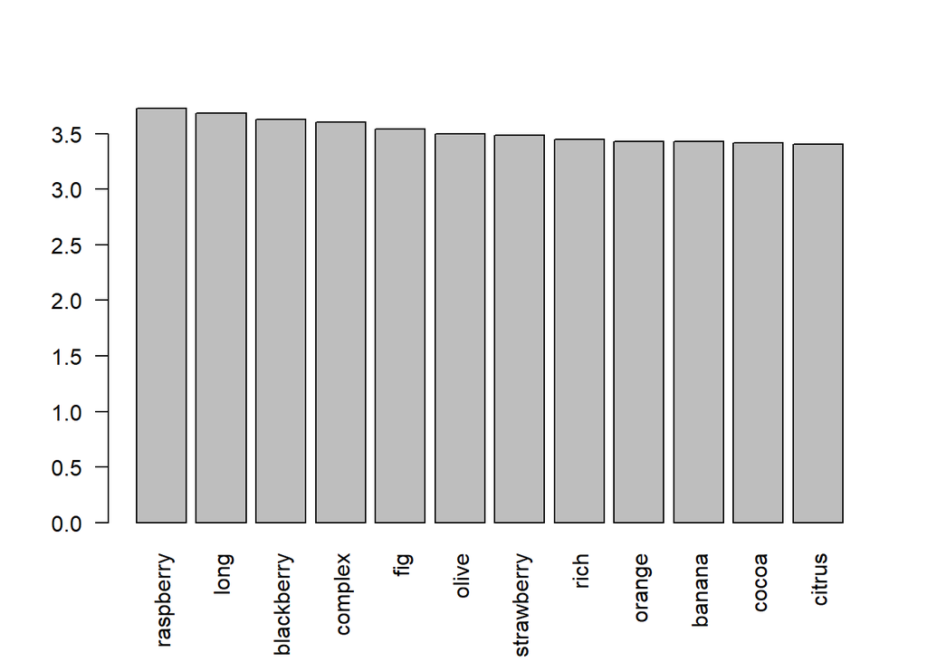

```r
barplot(charRank$one, names.arg = charRank$name, las =2)
```

This is a visualization of the top 12 characteristics of a good rating.

5. Rating of chocolate depending on how many ingredients there are

```r
threeIngredient <- choco$Ingredients == '3- B,S,C'
three <- choco[threeIngredient,]
```

```r
twoIngredients <- choco$Ingredients == '2- B,S'
two <- choco[twoIngredients,]
```

```r
fourIngredients <- choco$Ingredients == '4- B,S,C,V'
four <- choco[fourIngredients,]
```

```r
fiveIngedient <- choco$Ingredients == '5-B,S,C,V,Sa'
five <- choco[fiveIngedient,]
```

```r
sixIngredients <- choco$Ingredients == '6-B,S,C,V,L,Sa'
six <- choco[sixIngredients,]
```

```r
specialFour <- choco$Ingredients == '4- B,S*,C,Sa'
specFour <- choco[specialFour,]
```

```r
specialThree <- choco$Ingredients == '3- B,S*,C'
specThree <- choco[specialThree,]
```

```r
mean(two$Rating, na.rm = TRUE)
```

```
## [1] 3.214218
```

```r
mean(three$Rating, na.rm = TRUE)
```

```
## [1] 3.274859
```

```r
mean(four$Rating, na.rm = TRUE)
```

```
## [1] 2.970588
```

```r
mean(five$Rating, na.rm = TRUE)
```

```
## [1] 2.791667
```

```r
mean(six$Rating, na.rm = TRUE)
```

```
## [1] 2.9375
```

```r
mean(specThree$Rating, na.rm = TRUE)
```

```
## [1] 2.9375
```

```r
mean(specFour$Rating, na.rm = TRUE)
```

```
## [1] 3.1125
```